# Chapter 4 Analysis

Danielle Burgess

```r
knitr::opts_chunk$set(echo=TRUE, message=FALSE, warning=FALSE, fig.show='hold', results='hold')

library(here)
library(readxl)
library(tidyr)
library(dplyr)
library(ggplot2) #for plots
library(scales) #for percent()
library(lme4) #for glmer
library(plotrix) #for std.error()
library(emmeans) #for lsmeans
library(buildmer)
library(lmerTest) #for lmer p-values
library(pbkrtest)
library(DescTools) #for Entropy
```

```r
# import FCT data
Ch4FCT <- read_excel(path=here("tidy_data/Ch4FCT.xlsx"))
Ch4FCT <- Ch4FCT %>% rename(participant = player, condition = Condition)
# import production data
Ch4Prod <- read_excel(path=here("tidy_data/Ch4Prod.xlsx"),
                      col_types = c("numeric", "text", "text", "text",
                                    "text", "text", "text", "text",
                                    "text","numeric","numeric","text",
                                    "numeric","text", "numeric", "numeric", "numeric"))
Ch4Prod <- Ch4Prod %>% rename(participant = player, condition = Condition)
Ch4Prod$phase <- factor(Ch4Prod$phase,levels=c("NounProd","AffProd","NegProd","IntProd","NegProd2"))
# import negation data
Ch4NegProd <- read_excel(path=here("tidy_data/Ch4NegProd.xlsx"),
                      col_types = c("numeric", "text", "text", "text",
                                    "text", "text", "text", "text",
                                    "text","numeric","numeric","text",
                                    "numeric","text", "numeric", "numeric",
                                    "numeric","numeric","numeric"))
Ch4NegProd <- Ch4NegProd %>% rename(participant = player, condition = Condition)
Ch4NegProd$phase <- factor(Ch4NegProd$phase, levels=c("NegProd","IntProd","NegProd2"))
# import questionnaire data
ENGPostExpQ <- read_excel(path=here("tidy_data/ENGPostExpQ.xlsx"))
ENGPostExpQ <- subset(ENGPostExpQ, participant %in% Ch4Prod$participant)
ENGPostExpQ <- ENGPostExpQ %>% mutate_at(c('aoa','total','use_rate','understand_rate','media_exp_rate','social_exp_rate'), as.numeric)
```

# 1 Introduction

Is there a bias favoring preverbal negation in learning among English speakers in the US? Does the presence of a communicative context influence a preference for earlier negation?

Participants in this study were exposed to an artificial language that had a mixture of NegV and VNeg word orders, and the ratio of these orders was manipulated depending on experimental condition. Those in the Equiprobable Condition saw equal amounts of both orders, whereas those in the Majority Preverbal Negation Condition saw 75% NegV order, and those in the Majority Postverbal Negation Condition saw 75% VNeg order.

Participants were trained on the artificial language in three phases. First, they were exposed to nouns, then affirmative sentences, and finally negative sentences. Each exposure phase was followed by a comprehension test, which took the form of a 2-alternative forced choice task (abbreviated FCT here), and a production test, where participants typed descriptions of images in the artificial language. Following the negative sentence training, there were three critical production stages (recall 1, interaction, and recall 2), in which participants were asked to describe novel images withheld during the training phase in the artificial language. This file describes analysis of accuracy in each of these tests and analysis of word order preferences.

This R Markdown file contains the code used for data analysis and plotting.

# 2 Accuracy

In this section I examine overall accuracy in the comprehension (FCT) and production tasks.

## 2.1 FCT Accuracy

In each FCT trial, participants were presented with two images and a description in the artificial language and were asked to choose which image matched the description.

The lower mean accuracy in the Negative Sentence phase of the experiment is primarily driven by errors in the first trial of that stage. After failing a trial in this phase participants saw the reminder ‘Remember that negation refers to what did NOT happen’, and overall accuracy improves if the first trial is excluded.

```r
# the interaction phase also included a forced choice task, so add interaction phase to training fct data
Ch4Int <- Ch4Prod %>% filter(phase=="IntProd")
shared_cols <- names(Ch4Int)[names(Ch4Int) %in% names(Ch4FCT)]
Ch4FCT <- rbind(Ch4FCT[shared_cols],Ch4Int[shared_cols])

# accuracy and standard error by phase and condition
FCT_acc <- Ch4FCT %>%
  group_by(condition,phase) %>%
  summarise(mean = mean(trialSuccess),
            se = std.error(trialSuccess))
FCT_acc$phase <- factor(FCT_acc$phase,levels=c("NounFCT","AffFCT","NegFCT","IntProd"))

# qccuracy by participant
FCT_acc_byp <- Ch4FCT %>%
  group_by(participant,condition,phase) %>%
  summarise(mean = mean(trialSuccess),
            se = std.error(trialSuccess))
FCT_acc_byp$phase <- factor(FCT_acc_byp$phase,levels=c("NounFCT","AffFCT","NegFCT","IntProd"))
```

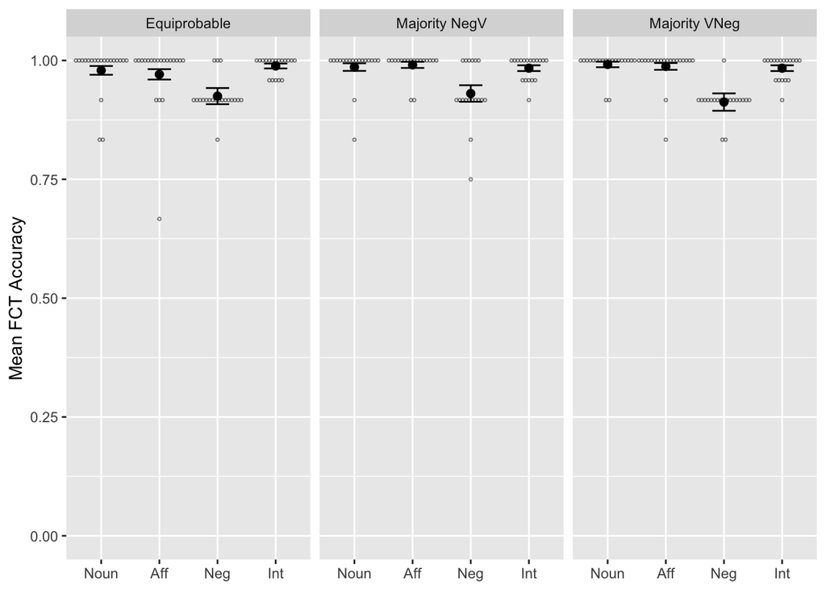

```r
Ch4FCTAcc <- ggplot(FCT_acc_byp, aes(y=mean, x=phase)) +
  geom_dotplot(position="dodge",binaxis="y", stackdir="center",dotsize=0.2,fill="white",alpha=0.5)+
  geom_point(data=FCT_acc, stat="identity",size = 2)+
  geom_errorbar(data=FCT_acc, aes(ymin=mean-se,ymax=mean+se),width=0.4)+
  scale_y_continuous(limits=c(0,1))+
  scale_x_discrete(labels = c('Noun','Aff','Neg','Int'))+
  facet_grid(~condition)+
  labs(y="Mean FCT Accuracy",x=NULL)
Ch4FCTAcc
ggsave(filename="Ch4FCTAcc.png",plot=Ch4FCTAcc,path=here("output"),width=6,height=4,units="in")
```

```r
# checking the source of low accuracy in NegFCT is first trial
trial1_negFCT <- Ch4FCT %>% filter(phase=="NegFCT") %>% group_by(participant) %>% slice(1)
# 22% accuracy on the first trial of the NegFCT task
trial1_negFCT_mean <- mean(trial1_negFCT$trialSuccess)
```

```r
# this code chunk is currently set not to evaluate on knit to lessen computing time
# find maximal model that will converge
max.model <- trialSuccess ~ condition * phase + (1|participant)
fct.m <- buildmer(max.model,data=Ch4FCT,family="binomial",buildmerControl=buildmerControl(direction='order', args=list(control=lmerControl(optimizer='bobyqa'))))
# maximal model that will converge:
# trialSuccess ~ condition * phase
(max.model <- formula(fct.m@model))
fct.m <- buildmer(max.model,data=Ch4FCT,family="binomial",buildmerControl=list(direction='backward', args=list(control=lmerControl(optimizer='bobyqa'))))
# model with best fit via backwards stepwise comparison:
# trialSuccess ~ 1 + phase
(max.model <- formula(fct.m@model))
# the model that best fits the data includes fixed effects for phase; the fixed effects for condition did not result in a significantly better fit, indicating that the input condition was not an important factor in explaining accuracy on the forced choice task.
```

## 2.2 Production Accuracy

In this file ‘strict accuracy’ refers to exact matches between the participant input and target after correcting for minor typos. ‘Loose accuracy’ counts trials where the Levenshtein distance from the target string was 5 or less (for instance, a response where only one lexical item was swapped out for another would be classified as accurate by this measure. Refer to the data preparation file to see how accuracy and Levenshtein distance was calculated in more detail.

```r
# calculate mean accuracy (strict and loose) by participant
prod_acc_byp <- Ch4Prod %>%
  group_by(participant,condition,phase) %>%
  summarise(acc_strict_mean = mean(acc),
            acc_loose_mean = mean(near_acc))

# calculate mean accuracy (strict and loose) and standard errors by phase and condition
prod_acc <- Ch4Prod %>%
  group_by(condition,phase) %>%
  summarise(acc_strict_mean = mean(acc),
            acc_strict_se = std.error(acc),
            acc_loose_mean = mean(near_acc),
            acc_loose_se = std.error(near_acc))
```

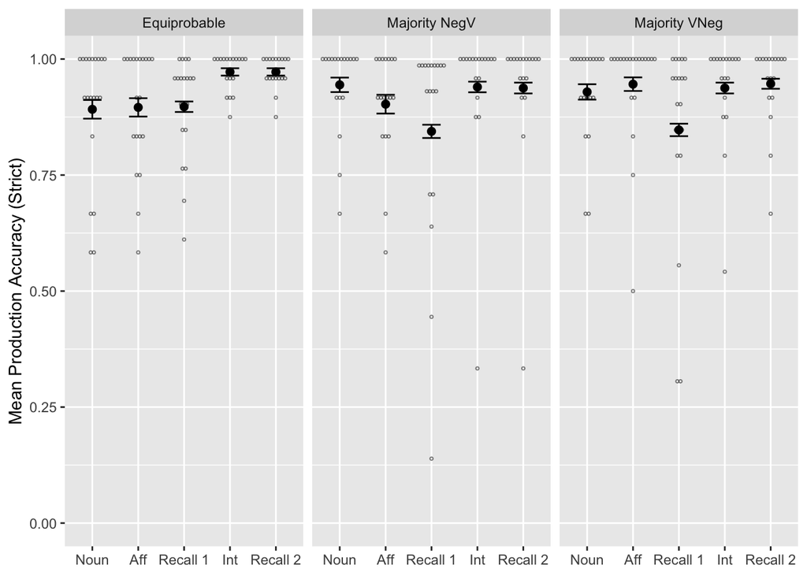

```r
Ch4ProdStrictAcc <- ggplot(prod_acc_byp, aes(y=acc_strict_mean, x=phase)) +
  geom_dotplot(position="dodge",binaxis="y", stackdir="center",dotsize=0.2,fill="white",alpha=0.5)+
  geom_point(data=prod_acc, stat="identity",size = 2)+
  geom_errorbar(data=prod_acc, aes(ymin=acc_strict_mean-acc_strict_se,ymax=acc_strict_mean+acc_strict_se),width=0.4)+
  scale_y_continuous(limits=c(0,1))+
  scale_x_discrete(labels = c('Noun','Aff','Recall 1','Int','Recall 2'))+
  facet_grid(~condition)+
  labs(y="Mean Production Accuracy (Strict)",x=NULL)
Ch4ProdStrictAcc
ggsave(filename="Ch4ProdStrictAcc.png",plot=Ch4ProdStrictAcc ,path=here("output"),width=6,height=4,units="in")
```

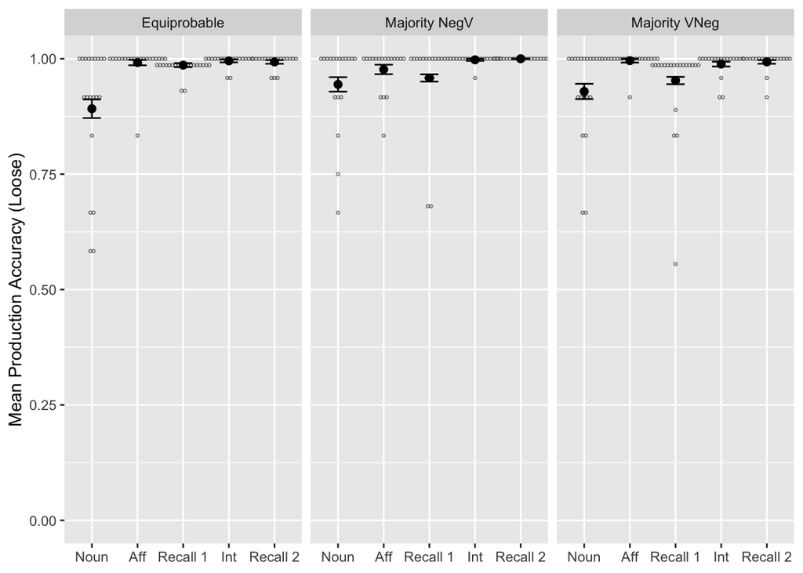

```r
Ch4ProdLooseAcc <- ggplot(prod_acc_byp, aes(y=acc_loose_mean, x=phase)) +
  geom_dotplot(position="dodge",binaxis="y", stackdir="center",dotsize=0.2,fill="white",alpha=0.5)+
  geom_point(data=prod_acc, stat="identity",size = 2)+
  geom_errorbar(data=prod_acc, aes(ymin=acc_loose_mean-acc_loose_se,ymax=acc_loose_mean+acc_loose_se),width=0.4)+
  scale_y_continuous(limits=c(0,1))+
  scale_x_discrete(labels = c('Noun','Aff','Recall 1','Int','Recall 2'))+
  facet_grid(~condition)+
  labs(y="Mean Production Accuracy (Loose)",x=NULL)
Ch4ProdLooseAcc
ggsave(filename="Ch4ProdLooseAcc.png",plot=Ch4ProdLooseAcc ,path=here("output"),width=6,height=4,units="in")
```

## 2.3 Excluded Critical Trials

```r
cr_excluded  <- sum(is.na(Ch4NegProd$NegVorder))
cr_total <- length(Ch4NegProd$NegVorder)
cr_percent <- percent(cr_excluded/cr_total, accuracy=0.1)
```

# 3 Word Order

This graph shows the proportion of NegV order within each condition and production phase.

```r
# calculate proportion NegV order by participant
NegV_byp <- Ch4NegProd %>%
  drop_na(NegVorder) %>%
  group_by(condition,participant,phase,group) %>%
  summarise(mean_negV = mean(NegVorder))

# summary statistics by condition and phase
NegV_summary <- NegV_byp %>%
  group_by(condition,phase) %>%
  summarise(mean = mean(mean_negV),
            se = std.error(mean_negV))
NegV_summary$input_prop <- case_when(
  NegV_summary$condition=="Majority VNeg" ~ 0.25,
  NegV_summary$condition=="Majority NegV" ~ 0.75,
  NegV_summary$condition=="Equiprobable" ~ 0.50)
```

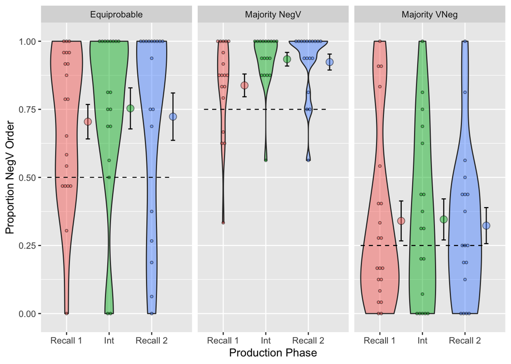

```r
Ch4NegVPlot <- ggplot(data=NegV_byp, aes(x=phase, fill=phase))+
  geom_violin(position=position_dodge(),aes(y=mean_negV),show.legend = FALSE, alpha=0.5)+
  geom_errorbar(data=NegV_summary, aes(ymin=input_prop,ymax=input_prop),linetype="dashed", size=.4)+
  geom_errorbar(data=NegV_summary, position=position_nudge(0.5),aes(y=mean, ymin=mean-se,ymax=mean+se),width=0.1)+
  geom_dotplot(position="dodge", aes(y=mean_negV), dotsize=0.3, binaxis="y", stackdir="center", alpha=0.5,show.legend = FALSE)+
  geom_dotplot(data=NegV_summary, aes(y=mean), dotsize=0.8, alpha=0.5, binaxis="y", stackdir="center", position_nudge(x=0.5),show.legend = FALSE)+
  facet_grid(~condition)+
  scale_x_discrete(labels=c("Recall 1","Int","Recall 2"))+
  labs(x = "Production Phase", y = "Proportion NegV Order")
Ch4NegVPlot

ggsave(filename="Ch4NegVPlot.png",plot=Ch4NegVPlot,path=here("output"),width=6,height=4,units="in")
```

## 3.1 Effect of Condition and Phase on NegV Order Use

In this section, I use mixed effects logistic regression modeling to answer the following questions:

1. Are participants in the Equiprobable condition producing NegV order significantly greater than chance?
- **Yes**. A model including NegV Order as the binary dependent variable, fixed effects of Condition (ref = Equiprobable) and Phase (ref = Recall 1), and their interaction, and random effects of participant nested in group, shows a significant positive intercept. This indicates that the choice of NegV order in the Equiprobable condition was significantly greater than chance in the Recall 1 phase of the Equiprobable Condition.

```r
# for this model Equiprobable is the ref level for Condition, Recall 1 is the ref level for Phase

#use buildmer to determine the maximal model that will converge
max.model <- NegVorder~condition*phase+(1|trialId)+(1|group/participant)
m <- buildmer(max.model,data=Ch4NegProd,family="binomial",buildmerControl=buildmerControl(direction='order',args=list(control=lmerControl(optimizer='bobyqa'))))
#buildmer suggests that the maximal model that will converge includes fixed effects for condition, phase, and their interaction, and random intercepts of trialId, group, and player nested in group
(max.model <- formula(m@model))

m <- buildmer(max.model,data=Ch4NegProd,family="binomial",buildmerControl=list(direction='backward', args=list(control=lmerControl(optimizer='bobyqa'))))
# model with best fit via backwards stepwise comparison:
# NegVorder~condition*phase+(1|group:participant)
(max.model <- formula(m@model))
```

```r
m.negvorder <- glmer(NegVorder~condition*phase+(1|group:participant),data=Ch4NegProd,family="binomial",control=glmerControl(optimizer="bobyqa"))
summary(m.negvorder)
```

```
## Generalized linear mixed model fit by maximum likelihood (Laplace
##   Approximation) [glmerMod]
##  Family: binomial  ( logit )
## Formula: NegVorder ~ condition * phase + (1 | group:participant)
##    Data: Ch4NegProd
## Control: glmerControl(optimizer = "bobyqa")
##
##      AIC      BIC   logLik deviance df.resid
##   2306.5   2366.5  -1143.2   2286.5     2973
##
## Scaled residuals:
##     Min      1Q  Median      3Q     Max
## -6.0635 -0.3422  0.1463  0.3977  5.9384
##
## Random effects:
##  Groups            Name        Variance Std.Dev.
##  group:participant (Intercept) 3.882    1.97
## Number of obs: 2983, groups:  group:participant, 54
##
## Fixed effects:
##                                      Estimate Std. Error z value Pr(>|z|)
## (Intercept)                            1.5340     0.4975   3.084 0.002044 **
## conditionMajority NegV                 0.8511     0.7071   1.204 0.228687
## conditionMajority VNeg                -2.6694     0.6969  -3.831 0.000128 ***
## phaseIntProd                           0.4329     0.2277   1.901 0.057238 .
## phaseNegProd2                          0.1613     0.2231   0.723 0.469748
## conditionMajority NegV:phaseIntProd    0.7720     0.3673   2.102 0.035557 *
## conditionMajority VNeg:phaseIntProd   -0.2674     0.3011  -0.888 0.374402
## conditionMajority NegV:phaseNegProd2   0.8631     0.3543   2.436 0.014836 *
## conditionMajority VNeg:phaseNegProd2  -0.1513     0.2982  -0.507 0.611895
## ---
## Signif. codes:  0 '***' 0.001 '**' 0.01 '*' 0.05 '.' 0.1 ' ' 1
##
## Correlation of Fixed Effects:
##             (Intr) cndMNV cndMVN phsInP phsNP2 cMNV:I cMVN:I cMNV:N
## cndtnMjrNgV -0.698
## cndtnMjrtVN -0.715  0.497
## phaseIntPrd -0.165  0.118  0.118
## phaseNgPrd2 -0.172  0.122  0.123  0.386
## cndtnMNV:IP  0.103 -0.145 -0.074 -0.620 -0.239
## cndtnMVN:IP  0.125 -0.089 -0.166 -0.756 -0.292  0.469
## cndtMNV:NP2  0.109 -0.152 -0.078 -0.243 -0.630  0.318  0.183
## cndtMVN:NP2  0.129 -0.091 -0.169 -0.288 -0.748  0.179  0.396  0.471
```

2. Do participants increase use of NegV order in the Interaction phase compared to the Recall 1 phase?
- Pairwise comparisons were conducted on the previously described model with Tukey method p-value adjustment using the emmeans package. These comparisons revealed that within each condition, the only significant differences in use of the NegV order between Production Stages were within the Majority NegV Condition; within this condition, there was significantly more NegV use in the Interaction Stage than the Recall 1 stage, and NegV use was also significantly greater in Recall 2 compared to Recall 1 indicating a lasting effect of interaction.

```r
negv_phase_pairwise <- lsmeans(m.negvorder, ~phase | condition)
pairs(negv_phase_pairwise)
```

```
## condition = Equiprobable:
##  contrast           estimate    SE  df z.ratio p.value
##  NegProd - IntProd  -0.43293 0.228 Inf  -1.901  0.1382
##  NegProd - NegProd2 -0.16126 0.223 Inf  -0.723  0.7499
##  IntProd - NegProd2  0.27167 0.250 Inf   1.087  0.5220
##
## condition = Majority NegV:
##  contrast           estimate    SE  df z.ratio p.value
##  NegProd - IntProd  -1.20495 0.288 Inf  -4.180  0.0001
##  NegProd - NegProd2 -1.02435 0.275 Inf  -3.722  0.0006
##  IntProd - NegProd2  0.18060 0.340 Inf   0.532  0.8557
##
## condition = Majority VNeg:
##  contrast           estimate    SE  df z.ratio p.value
##  NegProd - IntProd  -0.16552 0.197 Inf  -0.840  0.6780
##  NegProd - NegProd2 -0.00996 0.198 Inf  -0.050  0.9986
##  IntProd - NegProd2  0.15556 0.215 Inf   0.725  0.7486
##
## Results are given on the log odds ratio (not the response) scale.
## P value adjustment: tukey method for comparing a family of 3 estimates
```

## 3.2 Effect of Condition and Phase on Majority Order Use

3. Are participants in the Majority NegV condition more likely to boost the majority order (NegV) than participants in the Majority VNeg condition?
- **Yes**. I ran a mixed effects logistic regression model including Majority Order as the binary dependent variable, fixed effects of Condition (Helmert coded to test Majority VNeg vs Majority NegV, Equiprobable vs. combined mean of other two) and Phase (Helmert coded to test Interaction vs Recall 1, Recall 2 vs. combined mean of other two), and their interaction, and random effects of participant nested in group. Results revealed that the use of the majority order was significantly lower in the Majority VNeg Condition compared to the Majority NegV Condition, and that the majority word order was boosted more in the Interaction Phase than the Recall 1 Phase. The model also revealed significant interaction terms indicating that boosting of the majority order in the Interaction Stage compared to Recall 1 was signfiicantly smaller in the Majority VNeg Condition compared to the Majority NegV Condition.

```r
# relevel condition so we get appropriate contrasts for Helmert Coding
Ch4NegProd$condition <- factor(Ch4NegProd$condition,levels=c("Majority NegV","Majority VNeg","Equiprobable"))

contrasts(Ch4NegProd$condition) <- contr.helmert(3)
colnames(contrasts(Ch4NegProd$condition)) <- c("VNvNV", "EvVNNV")
contrasts(Ch4NegProd$phase) <- contr.helmert(3)
colnames(contrasts(Ch4NegProd$phase)) <- c("IvR1", "R2vIR1")
```

```r
#use buildmer to determine the maximal model that will converge
max.model <- majorityOrder~condition*phase+(1|trialId)+(1|group/participant)
m <- buildmer(max.model,data=Ch4NegProd,family="binomial",buildmerControl=buildmerControl(direction='order',args=list(control=lmerControl(optimizer='bobyqa'))))
#buildmer suggests that the maximal model that will converge includes fixed effects for condition, phase, and their interaction, and random intercepts of trialId, group, and player nested in group
(max.model <- formula(m@model))

m <- buildmer(max.model,data=Ch4NegProd,family="binomial",buildmerControl=list(direction='backward', args=list(control=lmerControl(optimizer='bobyqa'))))
# model with best fit via backwards stepwise comparison:
# majorityOrder~condition*phase+(1|group:participant)
(max.model <- formula(m@model))
```

```r
m.majorityorder <- glmer(majorityOrder~condition*phase+(1|group:participant),data=Ch4NegProd,family="binomial",control=glmerControl(optimizer="bobyqa"))
summary(m.majorityorder)
```

```
## Generalized linear mixed model fit by maximum likelihood (Laplace
##   Approximation) [glmerMod]
##  Family: binomial  ( logit )
## Formula: majorityOrder ~ condition * phase + (1 | group:participant)
##    Data: Ch4NegProd
## Control: glmerControl(optimizer = "bobyqa")
##
##      AIC      BIC   logLik deviance df.resid
##   2306.5   2366.5  -1143.2   2286.5     2973
##
## Scaled residuals:
##     Min      1Q  Median      3Q     Max
## -6.0635  0.0655  0.1829  0.4132  4.9352
##
## Random effects:
##  Groups            Name        Variance Std.Dev.
##  group:participant (Intercept) 3.882    1.97
## Number of obs: 2983, groups:  group:participant, 54
##
## Fixed effects:
##                             Estimate Std. Error z value Pr(>|z|)
## (Intercept)                  1.97907    0.28423   6.963 3.34e-12 ***
## conditionVNvNV              -1.02568    0.34638  -2.961 0.003065 **
## conditionEvVNNV             -0.12349    0.19897  -0.621 0.534818
## phaseIvR1                    0.24539    0.06948   3.532 0.000412 ***
## phaseR2vIR1                  0.04883    0.04315   1.132 0.257803
## conditionVNvNV:phaseIvR1    -0.34262    0.08729  -3.925 8.67e-05 ***
## conditionEvVNNV:phaseIvR1   -0.01446    0.04782  -0.303 0.762270
## conditionVNvNV:phaseR2vIR1  -0.05818    0.05469  -1.064 0.287414
## conditionEvVNNV:phaseR2vIR1 -0.03362    0.02941  -1.143 0.253049
## ---
## Signif. codes:  0 '***' 0.001 '**' 0.01 '*' 0.05 '.' 0.1 ' ' 1
##
## Correlation of Fixed Effects:
##             (Intr) cnVNNV cnEVNNV phsIR1 pR2IR1 cVNNV:I cEVNNV:I cVNNV:R
## condtnVNvNV -0.047
## cndtnEvVNNV -0.005  0.028
## phaseIvR1    0.067 -0.049 -0.017
## phaseR2vIR1  0.025 -0.016 -0.008  -0.182
## cndVNNV:IR1 -0.049  0.076  0.034  -0.304  0.121
## cnEVNNV:IR1 -0.016  0.034  0.055  -0.076  0.047  0.221
## cVNNV:R2IR1 -0.015  0.030  0.011   0.120 -0.329 -0.203  -0.087
## cEVNNV:R2IR -0.009  0.012  0.020   0.048 -0.104 -0.088  -0.160    0.241
```

# 4 Behavior Within Dyads

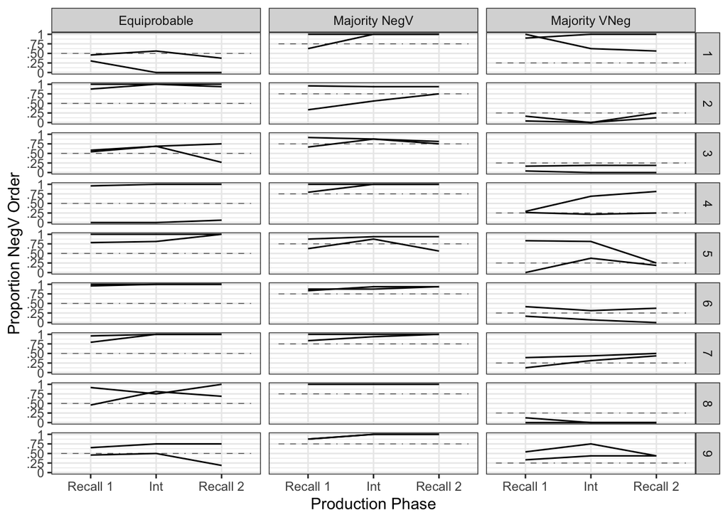

```r
#in order to make a nice looking graph, recode all the pairs separately for each condition

NegV_byp.equi <- subset(NegV_byp,condition=="Equiprobable")
NegV_byp.equi$DummyGroup <- as.factor(NegV_byp.equi$group)
levels(NegV_byp.equi$DummyGroup) <- 1:length(levels(NegV_byp.equi$DummyGroup))

NegV_byp.negV <- subset(NegV_byp,condition=="Majority NegV")
NegV_byp.negV$DummyGroup <- as.factor(NegV_byp.negV$group)
levels(NegV_byp.negV$DummyGroup) <- 1:length(levels(NegV_byp.negV$DummyGroup))

NegV_byp.Vneg <- subset(NegV_byp,condition=="Majority VNeg")
NegV_byp.Vneg$DummyGroup <- as.factor(NegV_byp.Vneg$group)
levels(NegV_byp.Vneg$DummyGroup) <- 1:length(levels(NegV_byp.Vneg$DummyGroup))

#recombine
NegV_byp.dummygroup <- rbind(NegV_byp.equi,NegV_byp.negV,NegV_byp.Vneg)
remove(NegV_byp.equi,NegV_byp.negV,NegV_byp.Vneg)
NegV_byp.dummygroup <- na.omit(NegV_byp.dummygroup)
NegV_byp.dummygroup$input_prop <- case_when(
  NegV_byp.dummygroup$condition=="Majority VNeg" ~ 0.25,
  NegV_byp.dummygroup$condition=="Majority NegV" ~ 0.75,
  NegV_byp.dummygroup$condition=="Equiprobable" ~ 0.50)

Ch4PlayerPairsPlot <- ggplot(NegV_byp.dummygroup,  aes(x=phase, y=mean_negV))+
  theme_bw()+
  geom_line(stat="identity",aes(group=participant),color="black")+
  geom_errorbar(aes(ymin=input_prop,ymax=input_prop),linetype="dashed", size=.2, alpha=0.3)+
  facet_grid(DummyGroup ~ condition)+
  theme(legend.position="none")+
  scale_x_discrete(labels=c("Recall 1","Int","Recall 2"))+
  scale_y_continuous(breaks=seq(0,1,1/4),labels=c("0",".25",".50",".75","1"))+
  labs(x = "Production Phase", y = "Proportion NegV Order")
Ch4PlayerPairsPlot

ggsave(filename="Ch4PlayerPairsPlot.png",plot=Ch4PlayerPairsPlot,path=here("output"),width=6,height=6,units="in")
```

## 4.1 Priming

Is the order of the current negative trial influenced by the order of the previous negative trial?

**Yes**

```r
# reorder data frame so that pairs are in trial order in interaction
Ch4Int <- Ch4NegProd %>% filter(phase=="IntProd")
Ch4Int <- Ch4Int[order(Ch4Int[,c("group")],Ch4Int[,c("interactivePeriod")]),]
Ch4Int$prevTrial <- NA
# add prevTrial column which holds 1 if previous trial was NegV order, 0 if not, NA if first trial
for (i in 1:length(Ch4Int$interactivePeriod)) {
  if (length(Ch4Int$group[i-1]==1L) && Ch4Int$group[i] == Ch4Int$group[i-1]) {
    Ch4Int$prevTrial[i] <- Ch4Int$NegVorder[i-1]
  }
  else {
    Ch4Int$prevTrial[i] <- NA
  }
}
Ch4Int$prevTrial <- factor(Ch4Int$prevTrial)
```

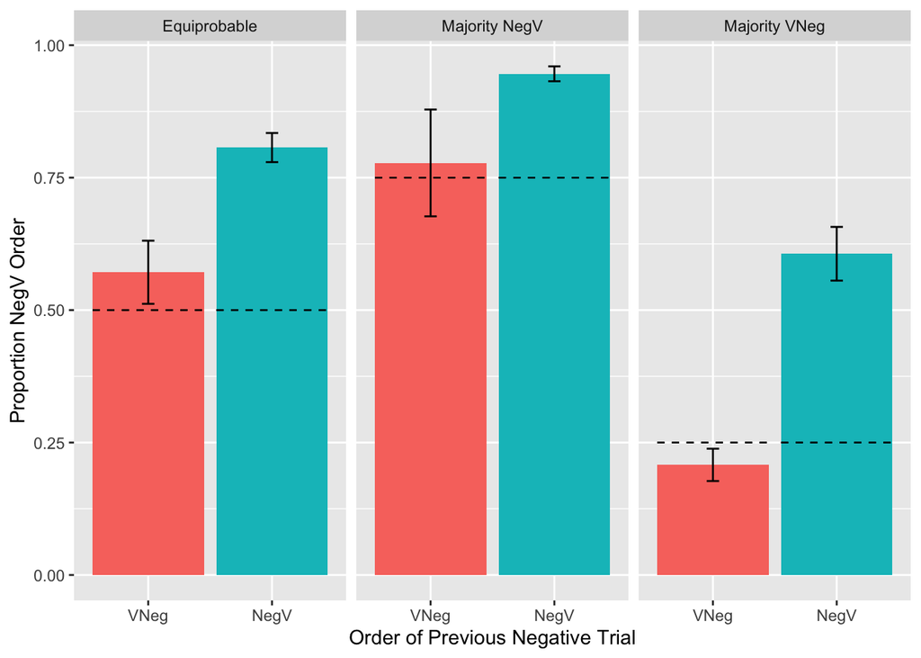

```r
# summary statistics by condition and previous trial
priming_summary <- Ch4Int[!is.na(Ch4Int$prevTrial),] %>%
  group_by(condition,prevTrial) %>%
  summarise(mean = mean(NegVorder,na.rm = TRUE),
            se = std.error(NegVorder,na.rm = TRUE))
priming_summary$input_prop <- case_when(
  priming_summary$condition=="Majority VNeg" ~ 0.25,
  priming_summary$condition=="Majority NegV" ~ 0.75,
  priming_summary$condition=="Equiprobable" ~ 0.50)

priming_summary$condition <- factor(priming_summary$condition,levels=c("Equiprobable","Majority NegV","Majority VNeg"))

Ch4PrimingPlot <- ggplot(data=priming_summary, aes(x=prevTrial,y=mean))+
  geom_bar(stat="identity", aes(fill=prevTrial),show.legend = FALSE)+
  geom_errorbar(data=priming_summary, aes(ymin=input_prop,ymax=input_prop),linetype="dashed", size=.4)+
  geom_errorbar(data=priming_summary, aes(y=mean, ymin=mean-se,ymax=mean+se),width=0.1)+
  facet_grid(~condition)+
  scale_x_discrete(labels=c("VNeg","NegV"))+
  labs(x = "Order of Previous Negative Trial", y = "Proportion NegV Order")
Ch4PrimingPlot

ggsave(filename="Ch4PrimingPlot.png",plot=Ch4PrimingPlot,path=here("output"),width=6,height=4,units="in")
```

```r
contrasts(Ch4Int$prevTrial) <- contr.helmert(2)

m.priming <- glmer(NegVorder~condition*prevTrial+(1|group/participant),data=Ch4Int,family="binomial",control=glmerControl(optimizer="bobyqa"))
summary(m.priming)
```

```
## Generalized linear mixed model fit by maximum likelihood (Laplace
##   Approximation) [glmerMod]
##  Family: binomial  ( logit )
## Formula: NegVorder ~ condition * prevTrial + (1 | group/participant)
##    Data: Ch4Int
## Control: glmerControl(optimizer = "bobyqa")
##
##      AIC      BIC   logLik deviance df.resid
##    593.7    631.5   -288.9    577.7      818
##
## Scaled residuals:
##     Min      1Q  Median      3Q     Max
## -4.3016 -0.1294  0.0742  0.3413  2.8323
##
## Random effects:
##  Groups            Name        Variance Std.Dev.
##  participant:group (Intercept) 2.857    1.690
##  group             (Intercept) 3.324    1.823
## Number of obs: 826, groups:  participant:group, 54; group, 27
##
## Fixed effects:
##                            Estimate Std. Error z value Pr(>|z|)
## (Intercept)                 1.63127    0.51177   3.188  0.00143 **
## conditionVNvNV             -2.65944    0.66585  -3.994 6.49e-05 ***
## conditionEvVNNV             0.22171    0.33775   0.656  0.51155
## prevTrial1                  0.37849    0.16354   2.314  0.02065 *
## conditionVNvNV:prevTrial1   0.03549    0.21100   0.168  0.86641
## conditionEvVNNV:prevTrial1 -0.04666    0.10449  -0.447  0.65523
## ---
## Signif. codes:  0 '***' 0.001 '**' 0.01 '*' 0.05 '.' 0.1 ' ' 1
##
## Correlation of Fixed Effects:
##             (Intr) cnVNNV cnEVNNV prvTr1 cVNNV:
## condtnVNvNV -0.252
## cndtnEvVNNV -0.013  0.046
## prevTrial1  -0.198  0.226  0.047
## cndtVNNV:T1  0.182 -0.180 -0.136  -0.508
## cndEVNNV:T1  0.062 -0.142 -0.146  -0.220  0.399
```

## 4.2 Asymmetric Accomodation Analysis

To measure whether asymmetric accomodation occurred during interaction, we can calculate the entropy of the system produced by each participant in each phase. Entropy measures how variable a participant’s productions are: entropy of 0 corresponds to a participant who consistently uses a single word order, and entropy is at a maximum (entropy = 1) when both word orders are used in equal proportion.

To test for asymmetric accomodation, we check whether participants who had categorical partners were more likely to adopt a more regular system during interaction than participants who had variable partners.

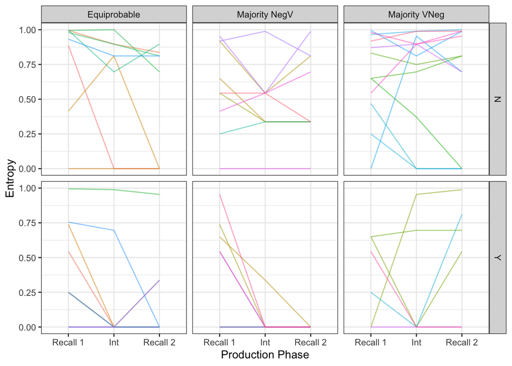

```r
# calculate entropy for each participant in each phase
for (i in 1:length(NegV_byp$mean_negV)) {
 NegV_byp$entropy[i] <- Entropy(c(NegV_byp$mean_negV[i],1-NegV_byp$mean_negV[i]))
}
NegV_byp <- NegV_byp[!is.na(NegV_byp$group),]
#reorder df for next step
NegV_byp <- NegV_byp[order(NegV_byp$group,NegV_byp$participant,NegV_byp$phase),]
NegV_byp$cat_partner <- NA
NegV_byp$cat <- NA
# code cat_partner: for each participant, mark Y when their partner was categorical during the interaction phase (i.e., used one order 100% of the time) and N otherwise
for (i in seq(from = 5, to = length(NegV_byp$entropy), by = 6)) {
  if (NegV_byp$entropy[i] == 0) {
    NegV_byp$cat_partner[(i-4):(i-2)] <- "Y"
  }
  else {
    NegV_byp$cat_partner[(i-4):(i-2)] <- "N"
  }
  if (NegV_byp$entropy[i-3] == 0) {
    NegV_byp$cat_partner[(i-1):(i+1)] <- "Y"
  }
  else {
    NegV_byp$cat_partner[(i-1):(i+1)] <- "N"
  }
}
# code cat: for each participant, mark Y if they were categorical in recall 1 and N otherwise
for (i in seq(from = 4, to = length(NegV_byp$entropy), by = 6)) {
  if (NegV_byp$entropy[i] == 0) {
    NegV_byp$cat[(i):(i+2)] <- "Y"
  }
  else {
    NegV_byp$cat[(i):(i+2)] <- "N"
  }
  if (NegV_byp$entropy[i-3] == 0) {
    NegV_byp$cat[(i-3):(i-1)] <- "Y"
  }
  else {
    NegV_byp$cat[(i-3):(i-1)] <- "N"
  }
}

Ch4EntropyPlot <- ggplot(NegV_byp,aes(x=phase,y=entropy))+
  theme_bw()+
  geom_line(stat="identity",aes(group=participant,color=participant),show.legend = FALSE, alpha=0.5)+
  facet_grid(cat_partner ~ condition)+
  scale_x_discrete(labels=c("Recall 1","Int","Recall 2"))+
  labs(x = "Production Phase", y = "Entropy")

Ch4EntropyPlot
```

Are variable users who interact with a categorical partner more likely to shift to a more regular system than those who interact with a variable partner?

```r
# relevel condition so we get appropriate contrasts
NegV_byp$condition <- factor(NegV_byp$condition,levels=c("Majority NegV","Majority VNeg","Equiprobable"))
NegV_byp$cat_partner <- factor(NegV_byp$cat_partner,levels=c("N","Y"))
NegV_byp$cat <- factor(NegV_byp$cat,levels=c("N","Y"))

contrasts(NegV_byp$condition) <- contr.treatment(3)
colnames(contrasts(NegV_byp$condition)) <- c("VNvNV", "EvNV")
contrasts(NegV_byp$phase) <- contr.treatment(3)
colnames(contrasts(NegV_byp$phase)) <- c("IvR1", "R2vR1")

m.asymm2_vR1 <- lmer(entropy~condition+phase*cat_partner+(1|group),data=subset(NegV_byp,cat=="N"))
summary(m.asymm2_vR1)
```

```
## Linear mixed model fit by REML. t-tests use Satterthwaite's method [
## lmerModLmerTest]
## Formula: entropy ~ condition + phase * cat_partner + (1 | group)
##    Data: subset(NegV_byp, cat == "N")
##
## REML criterion at convergence: 78.5
##
## Scaled residuals:
##      Min       1Q   Median       3Q      Max
## -2.34442 -0.54838  0.01091  0.57938  2.17027
##
## Random effects:
##  Groups   Name        Variance Std.Dev.
##  group    (Intercept) 0.04498  0.2121
##  Residual             0.07165  0.2677
## Number of obs: 126, groups:  group, 26
##
## Fixed effects:
##                         Estimate Std. Error       df t value Pr(>|t|)
## (Intercept)              0.56806    0.10535  6.58264   5.392  0.00124 **
## conditionVNvNV           0.12549    0.12084  3.89348   1.039  0.35916
## conditionEvNV            0.04633    0.12067  3.99860   0.384  0.72056
## phaseIvR1               -0.11282    0.07424 46.44528  -1.520  0.13537
## phaseR2vR1              -0.13713    0.07424 46.44528  -1.847  0.07109 .
## cat_partnerY             0.07913    0.11160 36.04609   0.709  0.48288
## phaseIvR1:cat_partnerY  -0.29886    0.12028 46.44528  -2.485  0.01663 *
## phaseR2vR1:cat_partnerY -0.25660    0.12028 46.44528  -2.133  0.03821 *
## ---
## Signif. codes:  0 '***' 0.001 '**' 0.01 '*' 0.05 '.' 0.1 ' ' 1
##
## Correlation of Fixed Effects:
##             (Intr) cnVNNV cndENV phsIR1 phR2R1 ct_prY pIR1:_
## condtnVNvNV -0.651
## conditnEvNV -0.567  0.511
## phaseIvR1   -0.352  0.000  0.000
## phaseR2vR1  -0.352  0.000  0.000  0.500
## cat_partnrY -0.458  0.108 -0.064  0.333  0.333
## phsIvR1:c_Y  0.217  0.000  0.000 -0.617 -0.309 -0.539
## phsR2vR1:_Y  0.217  0.000  0.000 -0.309 -0.617 -0.539  0.500
```

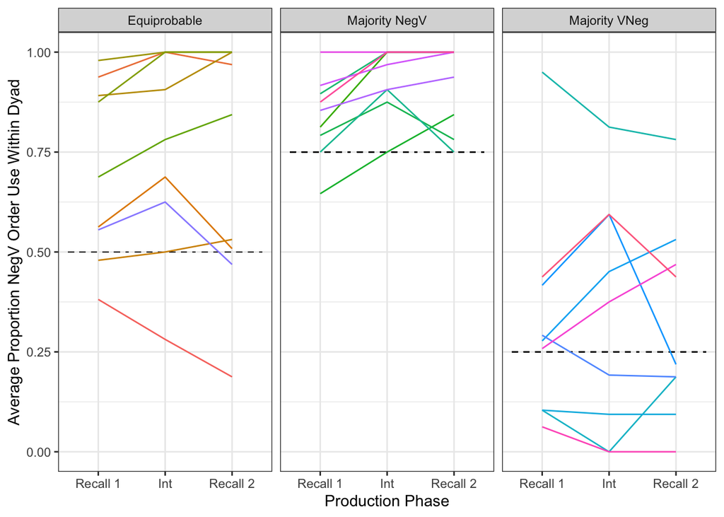

```r
# calculate mean negVorder use, minimum entropy, and mean entropy for each dyad
combined_system <- NegV_byp[!is.na(NegV_byp$group),] %>%
  group_by(condition,phase,group) %>%
  summarise(combined_negV = mean(mean_negV))


combined_system$input_prop <- case_when(
  combined_system$condition=="Majority VNeg" ~ 0.25,
  combined_system$condition=="Majority NegV" ~ 0.75,
  combined_system$condition=="Equiprobable" ~ 0.50)
combined_system$condition <- factor(combined_system$condition,levels=c("Equiprobable","Majority NegV","Majority VNeg"))


Ch4CombinedNegVPlot <- ggplot(combined_system,aes(x=phase,y=combined_negV))+
  theme_bw()+
  geom_errorbar(data=combined_system, aes(ymin=input_prop,ymax=input_prop),linetype="dashed",linewidth=0.3)+
  geom_line(stat="identity",aes(group=group,color=group),show.legend = FALSE)+
  facet_grid(~ condition)+
  scale_x_discrete(labels=c("Recall 1","Int","Recall 2"))+
  labs(x = "Production Phase", y = "Average Proportion NegV Order Use Within Dyad")
Ch4CombinedNegVPlot

ggsave(filename="Ch4CombinedNegVPlot.png",plot=Ch4CombinedNegVPlot,path=here("output"),width=6,height=4,units="in")
```

## 4.3 Alignment

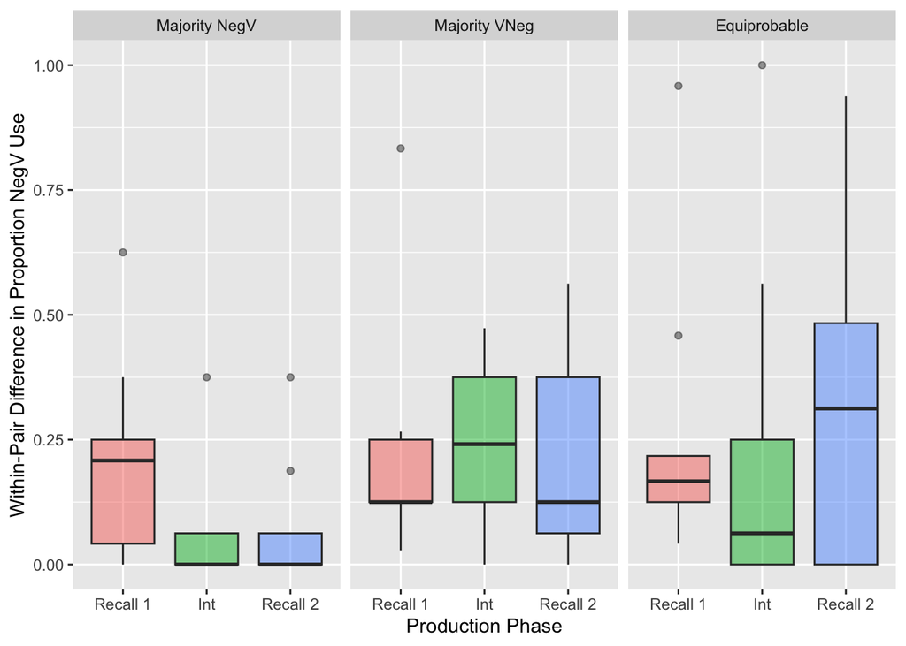

```r
#calculate within-pair difference in proportion NegV order use at each phase
NegV_pair.diff <- aggregate(
  list(difference=NegV_byp$mean_negV),
  list(group=NegV_byp$group, phase=NegV_byp$phase, condition=NegV_byp$condition),
  FUN=diff)
NegV_pair.diff$difference <- abs(NegV_pair.diff$difference)

Ch4PairDiffPlot <- ggplot(data=NegV_pair.diff,aes(x=phase,y=difference,fill=phase))+
  geom_boxplot(position="dodge",show.legend = FALSE, alpha=0.5)+
  labs(title=NULL,x = "Production Phase", y="Within-Pair Difference in Proportion NegV Use")+
  facet_grid(~ condition)+
  scale_x_discrete(labels=c("Recall 1","Int","Recall 2"))

Ch4PairDiffPlot
ggsave(filename="Ch4PairDiffPlot.png",plot=Ch4PairDiffPlot,path=here("output"),width=6,height=4,units="in")
```

```r
# relevel condition so we get appropriate contrasts for Helmert Coding
NegV_pair.diff$condition <- factor(NegV_pair.diff$condition,levels=c("Majority NegV","Majority VNeg","Equiprobable"))

contrasts(NegV_pair.diff$condition) <- contr.helmert(3)
colnames(contrasts(NegV_pair.diff$condition)) <- c("VNvNV", "EvVNNV")
contrasts(NegV_pair.diff$phase) <- contr.helmert(3)
colnames(contrasts(NegV_pair.diff$phase)) <- c("IvR1", "R2vIR1")

m.pair_diff <- lmer(difference~condition*phase+(1|group),data=NegV_pair.diff)
summary(m.pair_diff)
```

```
## Linear mixed model fit by REML. t-tests use Satterthwaite's method [
## lmerModLmerTest]
## Formula: difference ~ condition * phase + (1 | group)
##    Data: NegV_pair.diff
##
## REML criterion at convergence: 18.6
##
## Scaled residuals:
##      Min       1Q   Median       3Q      Max
## -1.94811 -0.51531 -0.04119  0.39218  2.68964
##
## Random effects:
##  Groups   Name        Variance Std.Dev.
##  group    (Intercept) 0.03091  0.1758
##  Residual             0.02568  0.1602
## Number of obs: 81, groups:  group, 27
##
## Fixed effects:
##                              Estimate Std. Error        df t value Pr(>|t|)
## (Intercept)                  0.201020   0.038233 24.000000   5.258 2.17e-05 ***
## conditionVNvNV               0.054104   0.046826 24.000000   1.155    0.259
## conditionEvVNNV              0.031948   0.027035 24.000000   1.182    0.249
## phaseIvR1                   -0.028856   0.021806 48.000000  -1.323    0.192
## phaseR2vIR1                 -0.004754   0.012590 48.000000  -0.378    0.707
## conditionVNvNV:phaseIvR1     0.040124   0.026707 48.000000   1.502    0.140
## conditionEvVNNV:phaseIvR1    0.006251   0.015419 48.000000   0.405    0.687
## conditionVNvNV:phaseR2vIR1   0.005934   0.015419 48.000000   0.385    0.702
## conditionEvVNNV:phaseR2vIR1  0.012074   0.008902 48.000000   1.356    0.181
## ---
## Signif. codes:  0 '***' 0.001 '**' 0.01 '*' 0.05 '.' 0.1 ' ' 1
##
## Correlation of Fixed Effects:
##             (Intr) cnVNNV cnEVNNV phsIR1 pR2IR1 cVNNV:I cEVNNV:I cVNNV:R
## condtnVNvNV 0.000
## cndtnEvVNNV 0.000  0.000
## phaseIvR1   0.000  0.000  0.000
## phaseR2vIR1 0.000  0.000  0.000   0.000
## cndVNNV:IR1 0.000  0.000  0.000   0.000  0.000
## cnEVNNV:IR1 0.000  0.000  0.000   0.000  0.000  0.000
## cVNNV:R2IR1 0.000  0.000  0.000   0.000  0.000  0.000   0.000
## cEVNNV:R2IR 0.000  0.000  0.000   0.000  0.000  0.000   0.000    0.000
```

# 5 Language Background

Besides English, the languages that participants most frequently identified having used or studied were Spanish (n=33), French (n=17), German (n=10), and Mandarin Chinese (n=8).

```r
# combine Mandarin, Mandarin Chinese, and Chinese
ENGPostExpQ$language <- gsub("Mandarin Chinese", "Chinese", ENGPostExpQ$language)
ENGPostExpQ$language <- gsub("Mandarin", "Chinese", ENGPostExpQ$language)

ENGLangExp <- ENGPostExpQ %>%
  group_by(language) %>%
  summarise(count = n(),
            mean_aoa = mean(aoa, na.rm=TRUE),
            se_aoa = std.error(aoa,na.rm=TRUE),
            mean_total = mean(total, na.rm=TRUE),
            mean_use = mean(use_rate, na.rm=TRUE),
            mean_understand = mean(understand_rate, na.rm=TRUE),
            mean_media_exp = mean(media_exp_rate, na.rm=TRUE),
            mean_social_exp = mean(social_exp_rate, na.rm=TRUE))
```